# E-handelsanalys

Grupp 5

2026-04-02

# E-handelsanalys

Syftet med analysen är att skapa en bättre förståelse för försäljning, kundbeteende och returer i e-handeln.

Analysen fokuserar på följande frågeställningar:

1. Finns det samband mellan rabatt och ordervärde?
2. Finns det tecken på att längre leveranstid hänger ihop med fler returer?
3. Skiljer sig köpbeteendet mellan nya, återkommande och VIP-kunder?

## 1) Dataförståelse

```r
glimpse(orders_raw)
```

```
## Rows: 1,000
## Columns: 16
## $ order_id            <chr> "O2025001", "O2025002", "O2025003", "O2025004", "O2025005", "O2025006", "O2025007", "O2025008", "O2025009", "O2025010", "O2025011", "O2025012", "O2025013", "O2025014", "O~
## $ order_date          <date> 2025-04-25, 2025-12-26, 2025-11-06, 2025-10-09, 2025-05-02, 2025-11-21, 2025-02-27, 2025-06-19, 2025-03-18, 2025-01-01, 2025-07-22, 2025-01-15, 2025-05-27, 2025-02-15, 2~
## $ customer_id         <chr> "C1198", "C1212", "C1096", "C1160", "C1063", "C1093", "C1238", "C1218", "C1240", "C1129", "C1046", "C1093", "C1089", "C1042", "C1052", "C1141", "C1164", "C1162", "C1043",~
## $ customer_segment    <chr> "Consumer", "Corporate", "Consumer", "Consumer", "Consumer", "Small Business", "Small Business", "Consumer", "Consumer", "Small Business", "Corporate", "Small Business", ~
## $ customer_type       <chr> "VIP", "New", "Returning", "New", "Returning", "Returning", "Returning", "VIP", "Returning", "New", "New", "Returning", "Returning", "Returning", "Returning", "Returning"~
## $ region              <chr> "South", "South", "North", "East", "East", "West", "West", "North", "South", "North", "North", "West", "South", "North", "West", "South", "East", "South", "South", "South~
## $ city                <chr> "Helsingborg", "Malmo", "Uppsala", "Orebro", "Linkoping", "Boras", "Gothenburg", "Vasteras", "Lund", "Vasteras", "Stockholm", "Boras", "Lund", "Uppsala", "Boras", "Malmo"~
## $ product_category    <chr> "Beauty", "Fashion", "Sports", "Fashion", "Beauty", "Fashion", "Fashion", "Home", "Fashion", "Home", "Beauty", "Sports", "Fashion", "Home", "Sports", "Beauty", "Home", "F~
## $ product_subcategory <chr> "Skincare", "Sportswear", "Fitness", "Shoes", "Skincare", "Shoes", "Shoes", "Furniture", "Sportswear", "Kitchen", "Haircare", "Team Sports", "Jackets", "Lighting", "Team ~
## $ payment_method      <chr> "Card", NA, "PayPal", "PayPal", "Invoice", "Card", "Gift Card", "Invoice", "Card", "Invoice", "Gift Card", "Invoice", "Swish", NA, "Card", "PayPal", "Swish", "Card", "Car~
## $ campaign_source     <chr> "Organic", "Organic", "Organic", "Affiliate", "Paid Search", "Paid Search", "Organic", "Affiliate", "Organic", "Social", "Social", "Social", "Social", "Email", "Social", ~
## $ quantity            <dbl> 4, 1, 1, 1, 2, 3, 1, 1, 4, 2, 1, 1, 1, 1, 1, 1, 2, 1, 1, 1, 1, 1, 2, 2, 1, 1, 1, 1, 1, 1, 1, 1, 2, 1, 1, 1, 1, 1, 1, 1, 1, 2, 1, 2, 1, 1, 1, 1, 1, 1, 1, 2, 2, 1, 1, 1, 1,~
## $ unit_price          <dbl> 33.90, 91.08, 190.22, 144.56, 52.01, 120.84, 97.55, 1051.52, 82.84, 164.19, 38.97, 105.58, 203.50, 162.61, 96.08, 44.96, 81.77, 175.92, 73.27, 45.73, 90.24, 143.93, 109.3~
## $ discount_pct        <dbl> 0.182, 0.013, 0.000, 0.042, 0.091, NA, 0.055, 0.120, 0.041, 0.058, 0.028, 0.045, 0.055, 0.137, 0.088, 0.002, 0.032, 0.143, 0.000, 0.107, 0.014, 0.068, 0.043, 0.036, 0.036~
## $ shipping_days       <dbl> 3, 2, 3, 5, 4, 4, 1, 5, 3, 5, 2, 4, 2, 4, 3, 5, 5, 3, 2, 3, 4, 3, 6, 2, 4, 5, 1, 2, 4, 4, 4, 1, 3, 4, 5, 3, 3, 4, NA, 1, 1, 5, 4, 5, 2, 4, 3, 1, 7, 4, 1, 6, 2, 3, 6, 5, 3~
## $ returned            <chr> "Yes", "No", "No", "No", "No", "Yes", "No", "No", "No", "No", "No", "No", "No", "No", "No", "No", "No", "No", "No", "No", "Yes", "No", "No", "No", "No", "No", "No", "No",~
```

```r
skim_without_charts(orders_raw)
```

Data summary

| Name | orders_raw |
| --- | --- |
| Number of rows | 1000 |
| Number of columns | 16 |
| _______________________ |  |
| Column type frequency: |  |
| character | 11 |
| Date | 1 |
| numeric | 4 |
| ________________________ |  |
| Group variables | None |

**Variable type: character**

| skim_variable | n_missing | complete_rate | min | max | empty | n_unique | whitespace |
| --- | --- | --- | --- | --- | --- | --- | --- |
| order_id | 0 | 1.00 | 8 | 8 | 0 | 1000 | 0 |
| customer_id | 0 | 1.00 | 5 | 5 | 0 | 255 | 0 |
| customer_segment | 0 | 1.00 | 8 | 14 | 0 | 3 | 0 |
| customer_type | 0 | 1.00 | 3 | 9 | 0 | 3 | 0 |
| region | 0 | 1.00 | 4 | 5 | 0 | 4 | 0 |
| city | 21 | 0.98 | 4 | 11 | 0 | 16 | 0 |
| product_category | 0 | 1.00 | 4 | 11 | 0 | 5 | 0 |
| product_subcategory | 0 | 1.00 | 5 | 11 | 0 | 20 | 0 |
| payment_method | 25 | 0.98 | 4 | 9 | 0 | 7 | 0 |
| campaign_source | 31 | 0.97 | 5 | 12 | 0 | 12 | 0 |
| returned | 0 | 1.00 | 2 | 3 | 0 | 2 | 0 |

**Variable type: Date**

| skim_variable | n_missing | complete_rate | min | max | median | n_unique |
| --- | --- | --- | --- | --- | --- | --- |
| order_date | 0 | 1 | 2025-01-01 | 2025-12-31 | 2025-07-01 | 345 |

**Variable type: numeric**

| skim_variable | n_missing | complete_rate | mean | sd | p0 | p25 | p50 | p75 | p100 |
| --- | --- | --- | --- | --- | --- | --- | --- | --- | --- |
| quantity | 0 | 1.00 | 1.36 | 0.65 | 1 | 1.00 | 1.00 | 2.00 | 4.00 |
| unit_price | 0 | 1.00 | 258.30 | 300.39 | 8 | 73.26 | 129.27 | 313.15 | 1625.78 |
| discount_pct | 27 | 0.97 | 0.07 | 0.05 | 0 | 0.03 | 0.06 | 0.10 | 0.31 |
| shipping_days | 22 | 0.98 | 3.61 | 1.50 | 1 | 3.00 | 4.00 | 5.00 | 8.00 |

```r
orders_raw %>%
  arrange(desc(unit_price)) %>%
  select(product_category, product_subcategory, unit_price, quantity) %>%
  head(5)
```

```
## # A tibble: 5 x 4
##   product_category product_subcategory unit_price quantity
##   <chr>            <chr>                    <dbl>    <dbl>
## 1 Electronics      Laptop                   1626.        2
## 2 Electronics      Laptop                   1546.        2
## 3 Electronics      Laptop                   1535.        1
## 4 Electronics      Laptop                   1485.        1
## 5 Electronics      Laptop                   1478.        2
```

```r
orders_raw %>%
  distinct(city) %>%
  arrange(city)
```

```
## # A tibble: 17 x 1
##    city
##    <chr>
##  1 Boras
##  2 Gothenburg
##  3 Halmstad
##  4 Helsingborg
##  5 Linkoping
##  6 Lund
##  7 Malmo
##  8 Norrkoping
##  9 Orebro
## 10 STOCKHOLM
## 11 Stockholm
## 12 Uppsala
## 13 Vasteras
## 14 gothenburg
## 15 malmo
## 16 stockholm
## 17 <NA>
```

```r
orders_raw %>% count(customer_type, sort = TRUE)
```

```
## # A tibble: 3 x 2
##   customer_type     n
##   <chr>         <int>
## 1 Returning       613
## 2 New             245
## 3 VIP             142
```

```r
orders_raw %>% count(returned, sort = TRUE)
```

```
## # A tibble: 2 x 2
##   returned     n
##   <chr>    <int>
## 1 No         856
## 2 Yes        144
```

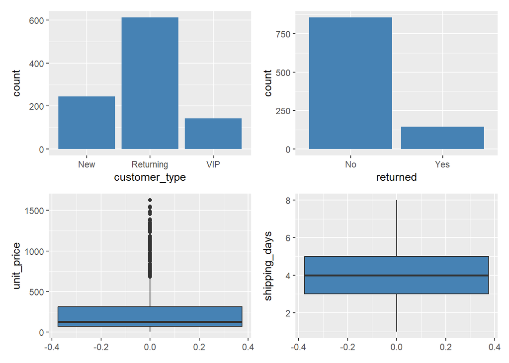

```r
p1 <- ggplot(orders_raw, aes(x = customer_type)) +
  geom_bar(fill = "steelblue")

p2 <- ggplot(orders_raw, aes(x = returned)) +
  geom_bar(fill = "steelblue")

p3 <- ggplot(orders_raw, aes(y = unit_price)) +
  geom_boxplot(fill = "steelblue")

p4 <- ggplot(orders_raw, aes(y = shipping_days)) +
  geom_boxplot(fill = "steelblue")

p1 + p2 + p3 + p4
```

Datasetet innehåller 1000 observationer och 16 variabler, bestående av både numeriska och kategoriska variabler.

Det finns vissa saknade värden, bland annat i city (21), payment_method (25), campaign_source (31), discount_pct (27) och shipping_days (22).

Majoriteten av ordrarna kommer från återkommande kunder (613), följt av nya kunder (245) och VIP-kunder (142).

Returandelen är cirka 14 %, vilket gör returer till ett relevant analysområde.

Priserna varierar kraftigt, där vissa produkter har mycket höga värden jämfört med övriga. Leveranstiden varierar mellan 1 och 8 dagar, med ett genomsnitt på cirka 3,6 dagar.

De viktigaste variablerna för analysen är discount_pct, order_value, shipping_days, returned och customer_type.

## 2) Datastädning och förberedelse

```r
orders_clean <- orders_raw

orders_clean <- orders_clean %>%
  mutate(returned = returned == "Yes")

orders_clean <- orders_clean %>%
  mutate(city = str_trim(city),
         city = str_to_title(city))

orders_clean <- orders_clean %>%
  mutate(
    order_value = unit_price * quantity,
    price_after_discount = order_value * (1 - discount_pct)
  )

orders_clean <- orders_clean %>%
  mutate(
    customer_segment = as.factor(customer_segment),
    customer_type = factor(customer_type,
                           levels = c("New", "Returning", "VIP"),
                           ordered = TRUE)
  )

str(orders_clean)
```

```
## tibble [1,000 x 18] (S3: tbl_df/tbl/data.frame)
##  $ order_id            : chr [1:1000] "O2025001" "O2025002" "O2025003" "O2025004" ...
##  $ order_date          : Date[1:1000], format: "2025-04-25" "2025-12-26" "2025-11-06" "2025-10-09" ...
##  $ customer_id         : chr [1:1000] "C1198" "C1212" "C1096" "C1160" ...
##  $ customer_segment    : Factor w/ 3 levels "Consumer","Corporate",..: 1 2 1 1 1 3 3 1 1 3 ...
##  $ customer_type       : Ord.factor w/ 3 levels "New"<"Returning"<..: 3 1 2 1 2 2 2 3 2 1 ...
##  $ region              : chr [1:1000] "South" "South" "North" "East" ...
##  $ city                : chr [1:1000] "Helsingborg" "Malmo" "Uppsala" "Orebro" ...
##  $ product_category    : chr [1:1000] "Beauty" "Fashion" "Sports" "Fashion" ...
##  $ product_subcategory : chr [1:1000] "Skincare" "Sportswear" "Fitness" "Shoes" ...
##  $ payment_method      : chr [1:1000] "Card" NA "PayPal" "PayPal" ...
##  $ campaign_source     : chr [1:1000] "Organic" "Organic" "Organic" "Affiliate" ...
##  $ quantity            : num [1:1000] 4 1 1 1 2 3 1 1 4 2 ...
##  $ unit_price          : num [1:1000] 33.9 91.1 190.2 144.6 52 ...
##  $ discount_pct        : num [1:1000] 0.182 0.013 0 0.042 0.091 NA 0.055 0.12 0.041 0.058 ...
##  $ shipping_days       : num [1:1000] 3 2 3 5 4 4 1 5 3 5 ...
##  $ returned            : logi [1:1000] TRUE FALSE FALSE FALSE FALSE TRUE ...
##  $ order_value         : num [1:1000] 135.6 91.1 190.2 144.6 104 ...
##  $ price_after_discount: num [1:1000] 110.9 89.9 190.2 138.5 94.6 ...
```

Datan har städats genom att:

- omvandla `returned` till en logisk variabel (TRUE/FALSE)
- standardisera `city` för att undvika olika stavningar
- skapa nya variabler:
  - `order_value` (unit_price * quantity)
  - `price_after_discount`
- konvertera variabler till rätt datatyper, där `customer_type` gjorts till en ordnad faktor (New, Returning, VIP)

Datan är nu strukturerad och redo för analys.

## 3) Statistiska sammanfattningar

```r
discount_impact <- orders_clean %>%
  summarise(
    correlation = cor(discount_pct, order_value, use = "complete.obs")
  )

discount_impact
```

```
## # A tibble: 1 x 1
##   correlation
##         <dbl>
## 1     0.00160
```

```r
shipping_return_summary <- orders_clean %>%
  group_by(returned) %>%
  summarise(
    avg_shipping_days = mean(shipping_days, na.rm = TRUE),
    order_count = n()
  )

shipping_return_summary
```

```
## # A tibble: 2 x 3
##   returned avg_shipping_days order_count
##   <lgl>                <dbl>       <int>
## 1 FALSE                 3.55         856
## 2 TRUE                  3.98         144
```

```r
customer_summary <- orders_clean %>%
  group_by(customer_type) %>%
  summarize(
    avg_order_value = mean(order_value, na.rm = TRUE),
    avg_discount = mean(discount_pct, na.rm = TRUE),
    return_rate = mean(returned, na.rm = TRUE)
  )

customer_summary
```

```
## # A tibble: 3 x 4
##   customer_type avg_order_value avg_discount return_rate
##   <ord>                   <dbl>        <dbl>       <dbl>
## 1 New                      368.       0.0658       0.180
## 2 Returning                331.       0.0628       0.132
## 3 VIP                      319.       0.114        0.134
```

För att besvara frågeställningarna genomfördes följande analyser:

Rabatter vs. Ordervärde: För att se om större rabatter får kunder att spendera mer pengar genomförde vi ett korrelationstest. Resultatet blev 0,0016, vilket är extremt nära noll. Detta visar att det inte finns något linjärt samband mellan rabattens storlek och det slutgiltiga ordervärdet. Kunder tenderar att köpa det de har tänkt köpa, oavsett om de får 5 % eller 20 % i rabatt.

Leveranstider vs. Returer: Vi undersökte om det fanns en koppling mellan längre leveranstider och antalet returer. Datan visar en tydlig samvariation: ordrar som behölls av kunden hade en genomsnittlig leveranstid på 3,55 dagar, medan varor som returnerades hade varit på väg i snitt 3,98 dagar (en skillnad på nästan en halv dag).

Observera: Vi kan inte fastställa att förseningen i sig är den direkta orsaken till returen (det kan finnas bakomliggande faktorer, t.ex. att skrymmande varor tar längre tid att frakta och returneras oftare). Det är dock en viktig varningssignal för logistikavdelningen att undersöka vidare, då längre väntetid kan öka risken för att kunden ångrar sitt köp.

## 4) Visualisering

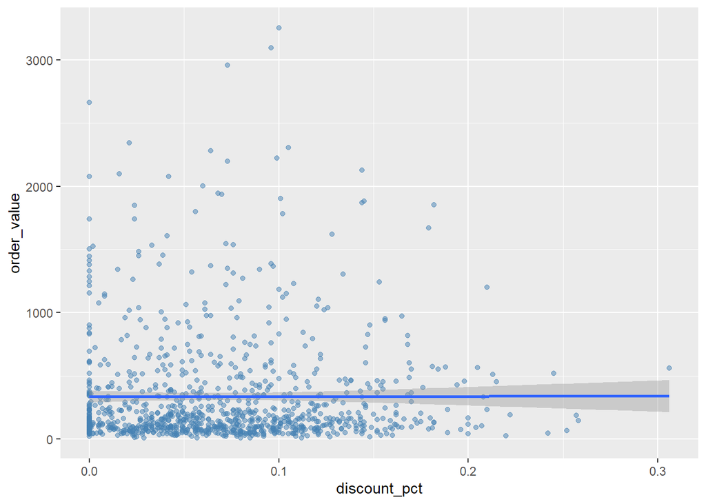

```r
p_discount <- ggplot(orders_clean, aes(x = discount_pct, y = order_value)) +
  geom_point(alpha = 0.5, color = "steelblue") +
  geom_smooth(method = "lm", se = TRUE)

p_discount
```

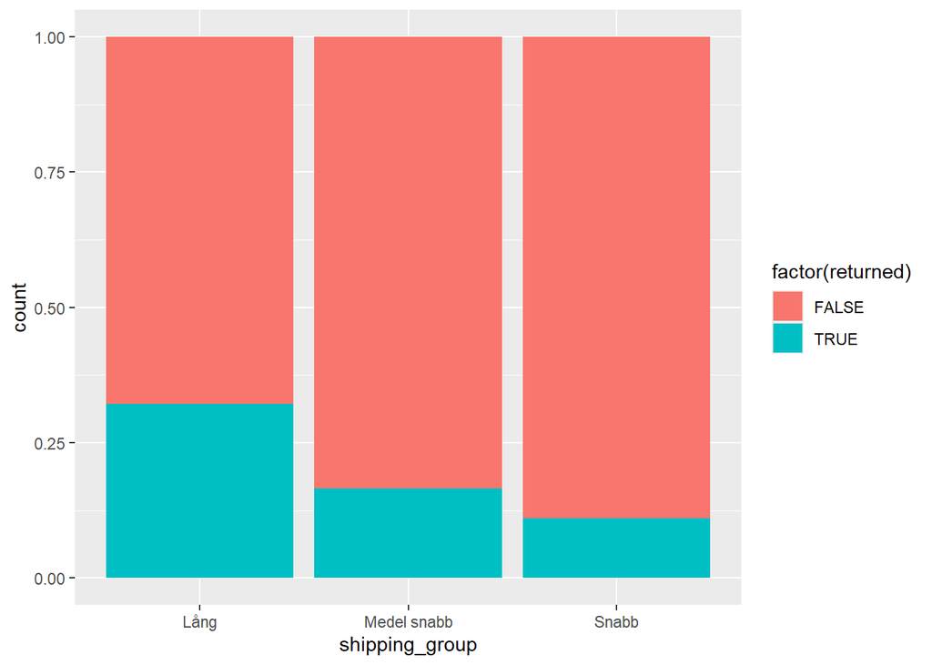

```r
orders_clean <- orders_clean %>%
  mutate(
    shipping_group = case_when(
      shipping_days <= 3 ~ "Snabb",
      shipping_days <= 7 ~ "Medel snabb",
      TRUE ~ "Lång"
    )
  )

p_shipping_return <- ggplot(orders_clean, aes(x = shipping_group, fill = factor(returned))) +
  geom_bar(position = "fill")

p_shipping_return
```

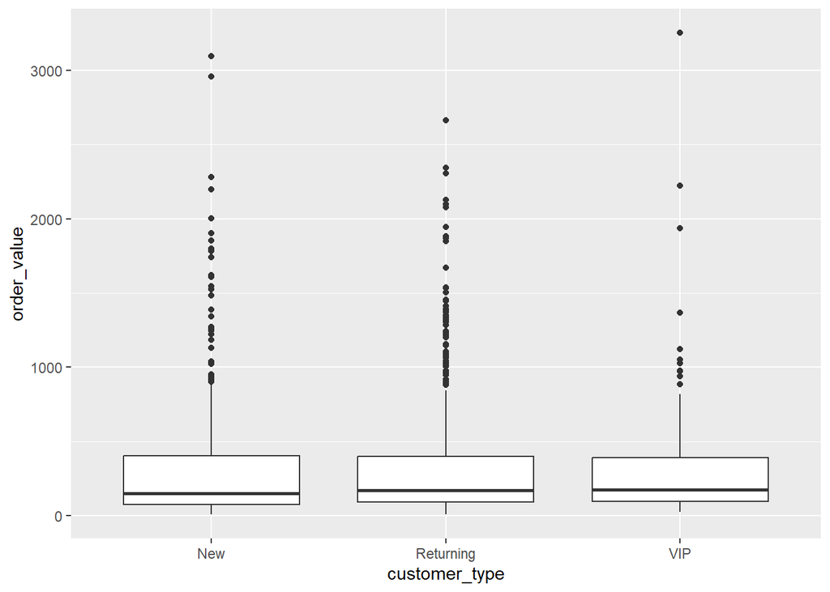

```r
p_customer_value <- ggplot(orders_clean, aes(x = customer_type, y = order_value)) +
  geom_boxplot()

p_customer_value
```

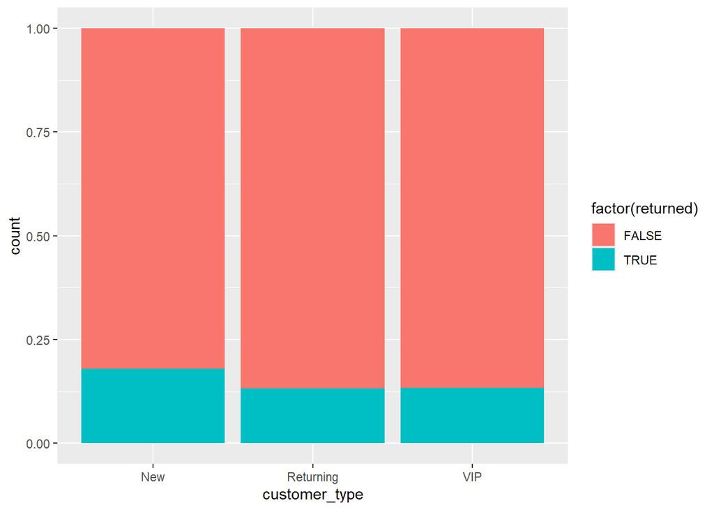

```r
p_customer_return <- ggplot(orders_clean, aes(x = customer_type, fill = factor(returned))) +
  geom_bar(position = "fill")

p_customer_return
```

Visualiseringarna bekräftar resultaten från de statistiska analyserna.

Spridningsdiagrammet visar att det inte finns något tydligt samband mellan rabatt och ordervärde, vilket stöds av den låga korrelationen.

Diagrammet över leveranstid visar att andelen returer är högst vid längre leveranstider och minskar vid snabbare leverans.

Boxplotten visar att ordervärdet är relativt liknande mellan kundtyperna, även om vissa variationer förekommer.

Diagrammet över returgrad per kundtyp visar att nya kunder har en något högre andel returer än övriga kundtyper.

## 5) Tolkning och slutsatser

### Tolkning

Analysen syftade till att undersöka samband mellan rabatt och ordervärde, leveranstid och returer samt skillnader i köpbeteende mellan olika kundtyper.

Resultaten visar att sambandet mellan rabatt och ordervärde är mycket svagt. Korrelationen är nära noll (≈ 0,002), och spridningen i visualiseringen är stor utan någon tydlig trend. Detta indikerar att rabatter inte har någon betydande påverkan på ordervärdet i detta dataset.

Däremot finns indikationer på ett samband mellan leveranstid och returgrad. Den genomsnittliga leveranstiden är högre för returnerade ordrar (≈ 3,98 dagar) jämfört med ej returnerade (≈ 3,55 dagar), och visualiseringen visar att andelen returer ökar vid längre leveranstider. Detta tyder på att leveranstiden kan påverka kundens benägenhet att returnera varor.

Analysen av kundtyper visar att det genomsnittliga ordervärdet är relativt likartat mellan grupperna, där nya kunder har något högre ordervärde än övriga. VIP-kunder har däremot högst genomsnittlig rabatt. Returgraden är något högre för nya kunder jämfört med återkommande och VIP-kunder. Boxplotten visar också att återkommande kunder uppvisar fler extremvärden i ordervärde.

### Slutsatser

Den viktigaste insikten från analysen är att leveranstid verkar ha större påverkan på kundbeteende än rabatter. Företaget bör därför prioritera effektiva och snabba leveranser för att minska returgraden och förbättra kundupplevelsen.

Resultaten visar även att rabatter inte har någon tydlig effekt på ordervärdet, vilket kan innebära att nuvarande rabattstrategi inte driver ökad försäljning. Detta kan motivera en översyn av hur och när rabatter används.

Vidare kan det vara relevant att rikta särskilda åtgärder mot nya kunder, eftersom de uppvisar en något högre returgrad.

### Rekommendationer

Baserat på analysen rekommenderas företaget att prioritera åtgärder som kan förbättra leveranstider, eftersom detta verkar ha en tydlig koppling till returgraden. Snabbare och mer tillförlitliga leveranser kan bidra till ökad kundnöjdhet och minskade kostnader för returer.

Vidare bör företagets användning av rabatter ses över. Eftersom analysen inte visar något tydligt samband mellan rabatt och ordervärde kan det vara mer effektivt att använda rabatter mer strategiskt, exempelvis riktat mot specifika kundgrupper eller kampanjer.

Det kan även vara värdefullt att arbeta mer aktivt med nya kunder, då dessa visar en något högre returgrad. Detta kan exempelvis göras genom tydligare produktinformation, rabatter eller förbättrad kundkommunikation.

### Begränsningar

Analysen visar samband men inte orsakssamband. Det innebär att vi inte kan fastställa att exempelvis längre leveranstid orsakar fler returer, endast att de samvarierar.

Datasetet är relativt begränsat och baseras på ett urval av data, vilket kan påverka generaliserbarheten av resultaten.

Det kan även finnas andra faktorer som påverkar resultaten, såsom produktkategori, prisnivå eller kundpreferenser, vilka inte har inkluderats i denna analys.

### Nästa steg

För att fördjupa analysen rekommenderas att inkludera fler variabler, såsom produktkategori eller kampanjkälla, för att undersöka om dessa påverkar ordervärde och returgrad.

Det kan också vara relevant att genomföra mer avancerade analyser, exempelvis regressionsanalyser, för att bättre förstå vilka faktorer som har störst påverkan på kundbeteende.

Slutligen kan det vara värdefullt att analysera data över tid för att identifiera säsongsmönster eller förändringar i kundbeteende.